# Predicting Wine Quality with Naive Bayes Algorithm

Naive Bayes Algorithm

Havva Nur Elveren

13 November 2021

# Objective: Predicting Wine Quality

Can we predict wine quality based on its features such as acidity, alcohol, sugar or sulfate level? In this project, we’ll predict Wine Quality with looking at the value of different features of a wine. We’ll use a data set that has been collected from red wine variants of the Portuguese “Vinho Verde” wine. If quality is greater than 6.5 it is considered as good wine, otherwise it is considered as bad wine.

# Data Description:

- 1.6K Row with 12 Column. You can download the data from the link https://www.kaggle.com/uciml/red-wine-quality-cortez-et-al-2009

```r
library(kableExtra)

dt <- data.frame(Name = c("fixed.acidity", "volatile.acidity", "citric.acid", "residual.sugar", "chlorides", "free.sulfur.dioxide", "total.sulfur.dioxide",
"density", "pH", "sulphates", "alcohol", "quality"),
Description = c("most acids involved with wine or fixed or nonvolatile (do not evaporate readily)", "the amount of acetic acid in wine, which at too high of levels can lead to an unpleasant, vinegar taste", "found in small quantities, citric acid can add 'freshness' and flavor to wines", "the amount of sugar remaining after fermentation stops, it's rare to find wines with less than 1 gram/liter and wines with greater than", "the amount of salt in the wine", "the free form of SO2 exists in equilibrium between molecular SO2 (as a dissolved gas) and bisulfite ion; it prevents", "amount of free and bound forms of S02; in low concentrations, SO2 is mostly undetectable in wine, but at free SO2", "the density of water is close to that of water depending on the percent alcohol and sugar content", "describes how acidic or basic a wine is on a scale from 0 (very acidic) to 14 (very basic); most wines are between 3-4 on the", "a wine additive which can contribute to sulfur dioxide gas (S02) levels, wich acts as an antimicrobial and", "the percent alcohol content of the wine","Score between 0 and 10, if quality > 6.5 it's Good, otherwise it is Bad "))

dt %>%
  kbl() %>%
  kable_styling()
```

| Name | Description |
| --- | --- |
| fixed.acidity | most acids involved with wine or fixed or nonvolatile (do not evaporate readily) |
| volatile.acidity | the amount of acetic acid in wine, which at too high of levels can lead to an unpleasant, vinegar taste |
| citric.acid | found in small quantities, citric acid can add ‘freshness’ and flavor to wines |
| residual.sugar | the amount of sugar remaining after fermentation stops, it’s rare to find wines with less than 1 gram/liter and wines with greater than |
| chlorides | the amount of salt in the wine |
| free.sulfur.dioxide | the free form of SO2 exists in equilibrium between molecular SO2 (as a dissolved gas) and bisulfite ion; it prevents |
| total.sulfur.dioxide | amount of free and bound forms of S02; in low concentrations, SO2 is mostly undetectable in wine, but at free SO2 |
| density | the density of water is close to that of water depending on the percent alcohol and sugar content |
| pH | describes how acidic or basic a wine is on a scale from 0 (very acidic) to 14 (very basic); most wines are between 3-4 on the |
| sulphates | a wine additive which can contribute to sulfur dioxide gas (S02) levels, wich acts as an antimicrobial and |
| alcohol | the percent alcohol content of the wine |
| quality | Score between 0 and 10, if quality > 6.5 it’s Good, otherwise it is Bad |

## Step 1: Load the Libraries

```r
library(ISLR)
library(caret)
library(readxl)
library(pROC)
library(lattice)
library(ggplot2)
library(dplyr)
library(e1071)
library(corrplot)
library(kknn)
library(ggplot2)
library(multiROC)
library(MLeval)
library(AppliedPredictiveModeling)
library(corrplot)
library(Hmisc)
library(dplyr)
library(quantmod)
```

## Step 2: Load the Data Set

```r
winedata <- read.csv("winequality-red.csv")
winedata <- data.frame(winedata, stringsAsFactors = FALSE, colnames<- TRUE )

str(winedata)
```

```
## 'data.frame':    1599 obs. of  13 variables:
##  $ fixed.acidity       : num  7.4 7.8 7.8 11.2 7.4 7.4 7.9 7.3 7.8 7.5 ...
##  $ volatile.acidity    : num  0.7 0.88 0.76 0.28 0.7 0.66 0.6 0.65 0.58 0.5 ...
##  $ citric.acid         : num  0 0 0.04 0.56 0 0 0.06 0 0.02 0.36 ...
##  $ residual.sugar      : num  1.9 2.6 2.3 1.9 1.9 1.8 1.6 1.2 2 6.1 ...
##  $ chlorides           : num  0.076 0.098 0.092 0.075 0.076 0.075 0.069 0.065 0.073 0.071 ...
##  $ free.sulfur.dioxide : num  11 25 15 17 11 13 15 15 9 17 ...
##  $ total.sulfur.dioxide: num  34 67 54 60 34 40 59 21 18 102 ...
##  $ density             : num  0.998 0.997 0.997 0.998 0.998 ...
##  $ pH                  : num  3.51 3.2 3.26 3.16 3.51 3.51 3.3 3.39 3.36 3.35 ...
##  $ sulphates           : num  0.56 0.68 0.65 0.58 0.56 0.56 0.46 0.47 0.57 0.8 ...
##  $ alcohol             : num  9.4 9.8 9.8 9.8 9.4 9.4 9.4 10 9.5 10.5 ...
##  $ quality             : int  5 5 5 6 5 5 5 7 7 5 ...
##  $ colnames....TRUE    : logi  TRUE TRUE TRUE TRUE TRUE TRUE ...
```

```r
summary(winedata)
```

```
##  fixed.acidity   volatile.acidity  citric.acid    residual.sugar
##  Min.   : 4.60   Min.   :0.1200   Min.   :0.000   Min.   : 0.900
##  1st Qu.: 7.10   1st Qu.:0.3900   1st Qu.:0.090   1st Qu.: 1.900
##  Median : 7.90   Median :0.5200   Median :0.260   Median : 2.200
##  Mean   : 8.32   Mean   :0.5278   Mean   :0.271   Mean   : 2.539
##  3rd Qu.: 9.20   3rd Qu.:0.6400   3rd Qu.:0.420   3rd Qu.: 2.600
##  Max.   :15.90   Max.   :1.5800   Max.   :1.000   Max.   :15.500
##    chlorides       free.sulfur.dioxide total.sulfur.dioxide    density
##  Min.   :0.01200   Min.   : 1.00       Min.   :  6.00       Min.   :0.9901
##  1st Qu.:0.07000   1st Qu.: 7.00       1st Qu.: 22.00       1st Qu.:0.9956
##  Median :0.07900   Median :14.00       Median : 38.00       Median :0.9968
##  Mean   :0.08747   Mean   :15.87       Mean   : 46.47       Mean   :0.9967
##  3rd Qu.:0.09000   3rd Qu.:21.00       3rd Qu.: 62.00       3rd Qu.:0.9978
##  Max.   :0.61100   Max.   :72.00       Max.   :289.00       Max.   :1.0037
##        pH          sulphates         alcohol         quality
##  Min.   :2.740   Min.   :0.3300   Min.   : 8.40   Min.   :3.000
##  1st Qu.:3.210   1st Qu.:0.5500   1st Qu.: 9.50   1st Qu.:5.000
##  Median :3.310   Median :0.6200   Median :10.20   Median :6.000
##  Mean   :3.311   Mean   :0.6581   Mean   :10.42   Mean   :5.636
##  3rd Qu.:3.400   3rd Qu.:0.7300   3rd Qu.:11.10   3rd Qu.:6.000
##  Max.   :4.010   Max.   :2.0000   Max.   :14.90   Max.   :8.000
##  colnames....TRUE
##  Mode:logical
##  TRUE:1599
##
##
##
##
```

```r
# If quality score is greater than 6.5 set quality as Good, otherwise set as Bad
winedata$quality[winedata$quality>6.5] <- 'Good'
winedata$quality[winedata$quality<= 6.5] <- 'Bad'
winedata$quality <- as.factor(winedata$quality)
table(winedata$quality)
```

```
##
##  Bad Good
## 1382  217
```

## Step 3: Prepare the Test and Training Data

```r
# Use the %75 of the data for training and the rest for testing the model
trainingIndex <- createDataPartition(y = winedata$quality, p = .75, list = FALSE)
winedata_train <- winedata[trainingIndex,]
winedata_test <- winedata[-trainingIndex,]

# with excluding the quality column, scale the data with z-score
trainX <- winedata_train[,names(winedata_train) != "quality"]
preProcValues <- preProcess(x = trainX,method = c("center", "scale"))
preProcValues
```

```
## Created from 1200 samples and 12 variables
##
## Pre-processing:
##   - centered (11)
##   - ignored (1)
##   - scaled (11)
```

## Step 4: Train the Model with Naive Bayes Algorithm

```r
# Train the model with navive bayes algorithm using naiveBayes function of e1071 packge
model <- naiveBayes(winedata_train, winedata_train$quality, laplace = 0)
model
```

```
##
## Naive Bayes Classifier for Discrete Predictors
##
## Call:
## naiveBayes.default(x = winedata_train, y = winedata_train$quality,
##     laplace = 0)
##
## A-priori probabilities:
## winedata_train$quality
##       Bad      Good
## 0.8641667 0.1358333
##
## Conditional probabilities:
##                       fixed.acidity
## winedata_train$quality     [,1]     [,2]
##                   Bad  8.234523 1.662453
##                   Good 8.869939 2.010286
##
##                       volatile.acidity
## winedata_train$quality      [,1]      [,2]
##                   Bad  0.5488042 0.1741217
##                   Good 0.4032209 0.1477158
##
##                       citric.acid
## winedata_train$quality      [,1]      [,2]
##                   Bad  0.2545805 0.1893413
##                   Good 0.3740491 0.1917484
##
##                       residual.sugar
## winedata_train$quality     [,1]     [,2]
##                   Bad  2.531967 1.421669
##                   Good 2.592025 1.182680
##
##                       chlorides
## winedata_train$quality       [,1]       [,2]
##                   Bad  0.08918708 0.04757936
##                   Good 0.07709816 0.03012980
##
##                       free.sulfur.dioxide
## winedata_train$quality     [,1]     [,2]
```

[output cut: 22 more lines]

```
##
##                       alcohol
## winedata_train$quality     [,1]      [,2]
##                   Bad  10.25434 0.9669581
##                   Good 11.49642 0.9607788
##
##                       quality
## winedata_train$quality Bad Good
##                   Bad    1    0
##                   Good   0    1
##
##                       colnames....TRUE
## winedata_train$quality FALSE TRUE
##                   Bad      0    1
##                   Good     0    1
```

```r
prediction <- predict(model, winedata_test, type="class")
confusionMatrix(prediction, winedata_test$quality)
```

```
## Confusion Matrix and Statistics
##
##           Reference
## Prediction Bad Good
##       Bad  345    2
##       Good   0   52
##
##                Accuracy : 0.995
##                  95% CI : (0.982, 0.9994)
##     No Information Rate : 0.8647
##     P-Value [Acc > NIR] : <2e-16
##
##                   Kappa : 0.9782
##
##  Mcnemar's Test P-Value : 0.4795
##
##             Sensitivity : 1.0000
##             Specificity : 0.9630
##          Pos Pred Value : 0.9942
##          Neg Pred Value : 1.0000
##              Prevalence : 0.8647
##          Detection Rate : 0.8647
##    Detection Prevalence : 0.8697
##       Balanced Accuracy : 0.9815
##
##        'Positive' Class : Bad
##
```

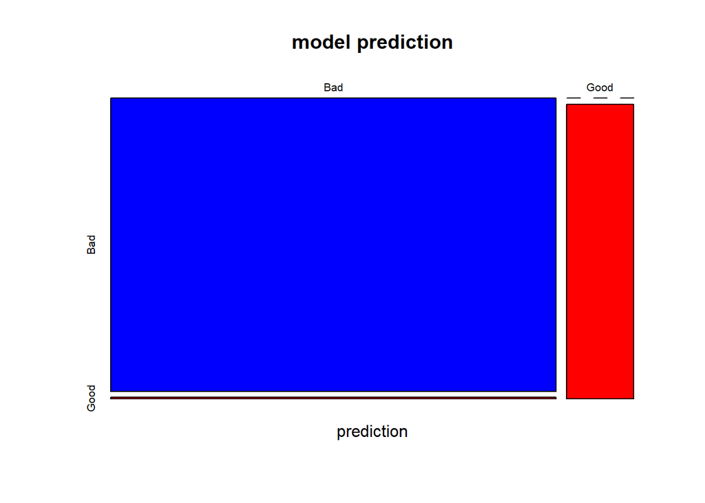

```r
pMatrix <- table(prediction, winedata_test$quality)
plot(pMatrix, type = "h", main= "model prediction", col= c("blue", "red"))
```

## Step 5: Improve the Model Performance

```r
# Improve the model performance with increasing the laplace value to 1
model <- naiveBayes(winedata_train, winedata_train$quality, laplace = 1)
model
```

```
##
## Naive Bayes Classifier for Discrete Predictors
##
## Call:
## naiveBayes.default(x = winedata_train, y = winedata_train$quality,
##     laplace = 1)
##
## A-priori probabilities:
## winedata_train$quality
##       Bad      Good
## 0.8641667 0.1358333
##
## Conditional probabilities:
##                       fixed.acidity
## winedata_train$quality     [,1]     [,2]
##                   Bad  8.234523 1.662453
##                   Good 8.869939 2.010286
##
##                       volatile.acidity
## winedata_train$quality      [,1]      [,2]
##                   Bad  0.5488042 0.1741217
##                   Good 0.4032209 0.1477158
##
##                       citric.acid
## winedata_train$quality      [,1]      [,2]
##                   Bad  0.2545805 0.1893413
##                   Good 0.3740491 0.1917484
##
##                       residual.sugar
## winedata_train$quality     [,1]     [,2]
##                   Bad  2.531967 1.421669
##                   Good 2.592025 1.182680
##
##                       chlorides
## winedata_train$quality       [,1]       [,2]
##                   Bad  0.08918708 0.04757936
##                   Good 0.07709816 0.03012980
##
##                       free.sulfur.dioxide
## winedata_train$quality     [,1]     [,2]
```

[output cut: 22 more lines]

```
##
##                       alcohol
## winedata_train$quality     [,1]      [,2]
##                   Bad  10.25434 0.9669581
##                   Good 11.49642 0.9607788
##
##                       quality
## winedata_train$quality          Bad         Good
##                   Bad  0.9990375361 0.0009624639
##                   Good 0.0060606061 0.9939393939
##
##                       colnames....TRUE
## winedata_train$quality        FALSE         TRUE
##                   Bad  0.0009624639 0.9990375361
##                   Good 0.0060606061 0.9939393939
```

```r
prediction <- predict(model, winedata_test, type="class")
confusionMatrix(prediction, winedata_test$quality)
```

```
## Confusion Matrix and Statistics
##
##           Reference
## Prediction Bad Good
##       Bad  345    2
##       Good   0   52
##
##                Accuracy : 0.995
##                  95% CI : (0.982, 0.9994)
##     No Information Rate : 0.8647
##     P-Value [Acc > NIR] : <2e-16
##
##                   Kappa : 0.9782
##
##  Mcnemar's Test P-Value : 0.4795
##
##             Sensitivity : 1.0000
##             Specificity : 0.9630
##          Pos Pred Value : 0.9942
##          Neg Pred Value : 1.0000
##              Prevalence : 0.8647
##          Detection Rate : 0.8647
##    Detection Prevalence : 0.8697
##       Balanced Accuracy : 0.9815
##
##        'Positive' Class : Bad
##
```

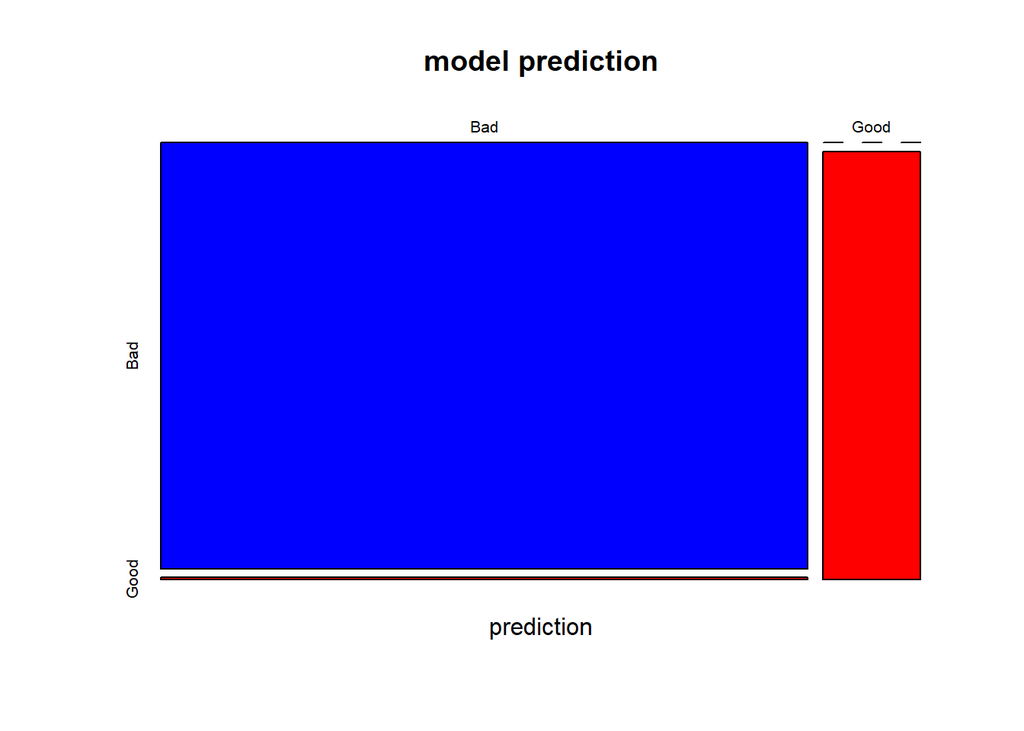

```r
pMatrix <- table(prediction, winedata_test$quality)
plot(pMatrix, type = "h", main= "model prediction", col= c("blue", "red"))
```

# Conculusion

In this project we predict wine quality with using Naive Bayes algorithm. In our data set each wine data has a qualith value which is a score between 0-10. If the quality score is greater than 6.5 than the wine is considered as good wine, otherwise it’s considered as bad wine.

Before training our model, we create the class factor with converting quality scores to a 2 level factor which is Good and Bad. After that we partition our data into test and training data and start training our model.

To train our model we use naviveBayes implementation of the e1071 package. In our first model we set the laplace value as 0, and in our second model we increase the laplace value to improve the model performance by mitigating the errors resulted by similarities in the data.

Both model gives almost perfect results predicting wine quality. Both model predicts the wine quality with more than %99 accuracy, even though our data set is not balanced and has more bad wine data than good wines.

Given the results of our training models, we can see that Naive Bayes is highly successful predicting wine quality on our data set.